# HW2-janelle-cordero

Janelle Cordero

January 28, 2019

# Data and EDA

The following dataset includes 1,599 red wine samples that were evaluated through chemical tests (e.g. pH, acidity, etc.) and graded by wine experts based on sensory tests on a scale of 0 (very bad) to 10 (very excellent). To create a classification problem, I divided the expert rating into 2 categories wines with a grade from 0-5 were classified “poor quality” and wines with a grade of 6-10 were classified “high quality.”

```r
wine <- read.table("winequality-red.csv",header=TRUE,sep=",")
kable(head(wine,10),caption="Wine Dataset") %>%
kable_styling(bootstrap_options = c("striped", "hover"))
```

Wine Dataset

| fixed.acidity | volatile.acidity | citric.acid | residual.sugar | chlorides | free.sulfur.dioxide | total.sulfur.dioxide | density | pH | sulphates | alcohol | quality |
| --- | --- | --- | --- | --- | --- | --- | --- | --- | --- | --- | --- |
| 7.4 | 0.70 | 0.00 | 1.9 | 0.076 | 11 | 34 | 0.9978 | 3.51 | 0.56 | 9.4 | 5 |
| 7.8 | 0.88 | 0.00 | 2.6 | 0.098 | 25 | 67 | 0.9968 | 3.20 | 0.68 | 9.8 | 5 |
| 7.8 | 0.76 | 0.04 | 2.3 | 0.092 | 15 | 54 | 0.9970 | 3.26 | 0.65 | 9.8 | 5 |
| 11.2 | 0.28 | 0.56 | 1.9 | 0.075 | 17 | 60 | 0.9980 | 3.16 | 0.58 | 9.8 | 6 |
| 7.4 | 0.70 | 0.00 | 1.9 | 0.076 | 11 | 34 | 0.9978 | 3.51 | 0.56 | 9.4 | 5 |
| 7.4 | 0.66 | 0.00 | 1.8 | 0.075 | 13 | 40 | 0.9978 | 3.51 | 0.56 | 9.4 | 5 |
| 7.9 | 0.60 | 0.06 | 1.6 | 0.069 | 15 | 59 | 0.9964 | 3.30 | 0.46 | 9.4 | 5 |
| 7.3 | 0.65 | 0.00 | 1.2 | 0.065 | 15 | 21 | 0.9946 | 3.39 | 0.47 | 10.0 | 7 |
| 7.8 | 0.58 | 0.02 | 2.0 | 0.073 | 9 | 18 | 0.9968 | 3.36 | 0.57 | 9.5 | 7 |
| 7.5 | 0.50 | 0.36 | 6.1 | 0.071 | 17 | 102 | 0.9978 | 3.35 | 0.80 | 10.5 | 5 |

```r
#converting "quality" to binary
wine$quality_binary <- ifelse(wine$quality<=5,0,1)
```

Below are descriptive statistics regarding the wine dataset. There are 744 low quality wines and 855 high quality wines so the dataset is fairly balanced. Many variables seem to have a dense range of values centered around he median with many outliers.

```r
kable(describe(wine),caption="Descriptive Statistics") %>%
kable_styling(bootstrap_options = c("striped", "hover"))
```

Descriptive Statistics

|  | vars | n | mean | sd | median | trimmed | mad | min | max | range | skew | kurtosis | se |
| --- | --- | --- | --- | --- | --- | --- | --- | --- | --- | --- | --- | --- | --- |
| fixed.acidity | 1 | 1599 | 8.3196373 | 1.7410963 | 7.90000 | 8.1525371 | 1.4826000 | 4.60000 | 15.90000 | 11.30000 | 0.9809084 | 1.1196987 | 0.0435410 |
| volatile.acidity | 2 | 1599 | 0.5278205 | 0.1790597 | 0.52000 | 0.5180679 | 0.1779120 | 0.12000 | 1.58000 | 1.46000 | 0.6703331 | 1.2126893 | 0.0044779 |
| citric.acid | 3 | 1599 | 0.2709756 | 0.1948011 | 0.26000 | 0.2612881 | 0.2520420 | 0.00000 | 1.00000 | 1.00000 | 0.3177403 | -0.7930455 | 0.0048716 |
| residual.sugar | 4 | 1599 | 2.5388055 | 1.4099281 | 2.20000 | 2.2583528 | 0.4447800 | 0.90000 | 15.50000 | 14.60000 | 4.5321399 | 28.4850200 | 0.0352592 |
| chlorides | 5 | 1599 | 0.0874665 | 0.0470653 | 0.07900 | 0.0802350 | 0.0148260 | 0.01200 | 0.61100 | 0.59900 | 5.6696937 | 41.5259635 | 0.0011770 |
| free.sulfur.dioxide | 6 | 1599 | 15.8749218 | 10.4601570 | 14.00000 | 14.5772834 | 10.3782000 | 1.00000 | 72.00000 | 71.00000 | 1.2482220 | 2.0072212 | 0.2615857 |
| total.sulfur.dioxide | 7 | 1599 | 46.4677924 | 32.8953245 | 38.00000 | 41.8430913 | 26.6868000 | 6.00000 | 289.00000 | 283.00000 | 1.5126890 | 3.7856764 | 0.8226402 |
| density | 8 | 1599 | 0.9967467 | 0.0018873 | 0.99675 | 0.9967362 | 0.0016753 | 0.99007 | 1.00369 | 0.01362 | 0.0711540 | 0.9225000 | 0.0000472 |
| pH | 9 | 1599 | 3.3111132 | 0.1543865 | 3.31000 | 3.3090945 | 0.1482600 | 2.74000 | 4.01000 | 1.27000 | 0.1933203 | 0.7959191 | 0.0038609 |
| sulphates | 10 | 1599 | 0.6581488 | 0.1695070 | 0.62000 | 0.6374473 | 0.1186080 | 0.33000 | 2.00000 | 1.67000 | 2.4241176 | 11.6615285 | 0.0042390 |
| alcohol | 11 | 1599 | 10.4229831 | 1.0656676 | 10.20000 | 10.3100312 | 1.0378200 | 8.40000 | 14.90000 | 6.50000 | 0.8592144 | 0.1916586 | 0.0266500 |
| quality | 12 | 1599 | 5.6360225 | 0.8075694 | 6.00000 | 5.5886027 | 1.4826000 | 3.00000 | 8.00000 | 5.00000 | 0.2173931 | 0.2879148 | 0.0201955 |
| quality_binary | 13 | 1599 | 0.5347092 | 0.4989499 | 1.00000 | 0.5433255 | 0.0000000 | 0.00000 | 1.00000 | 1.00000 | -0.1390420 | -1.9819056 | 0.0124776 |

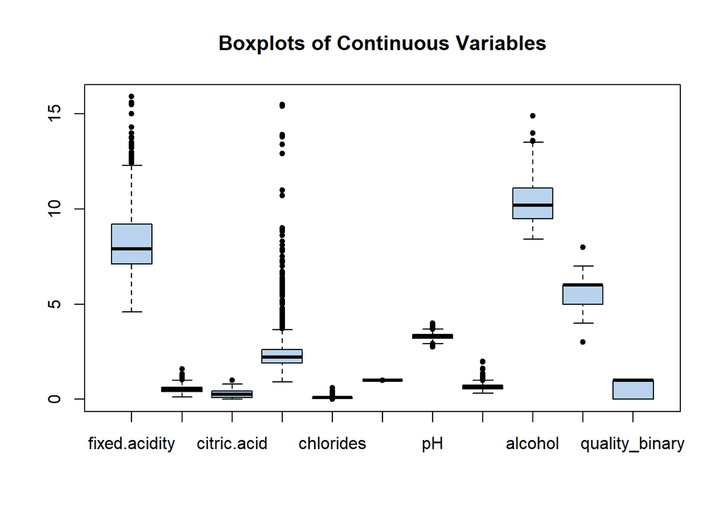

```r
boxplot(wine[-c(6,7)],main="Boxplots of Continuous Variables",col="slategray2",pch=20)
```

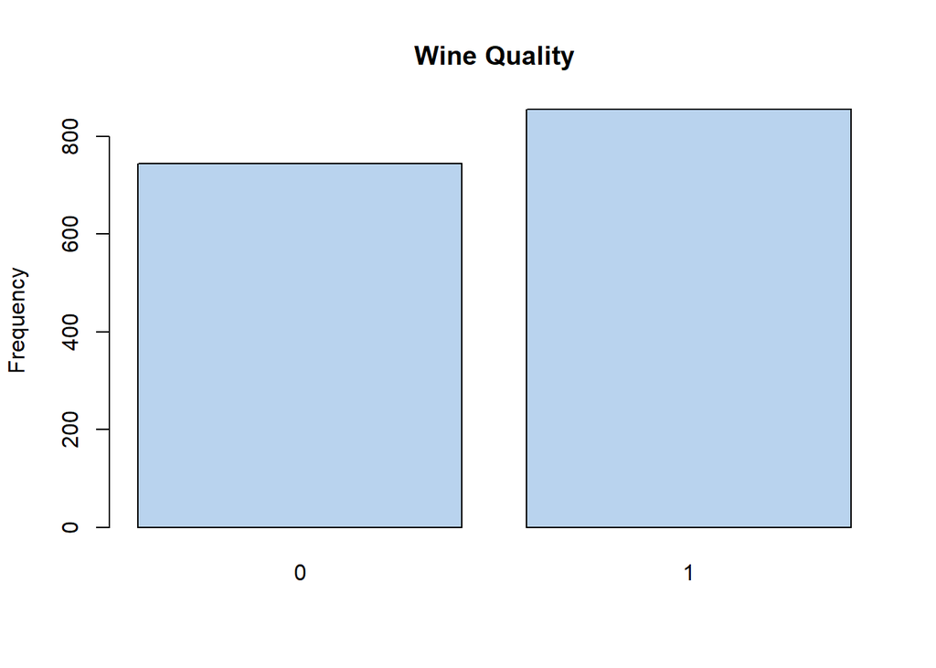

```r
plot(as.factor(wine$quality_binary),main="Wine Quality",ylab="Frequency",col="slategray2")
```

Wine quality seems to have the highest correlation with **alcohol** and **volatile acidity**, so these variables may warrant more investigation and appear to be significant when modeling. Logistic Regression assumes that independent variables are not too highly correlated. The largest correlation in this dataset is $|0.68|$.

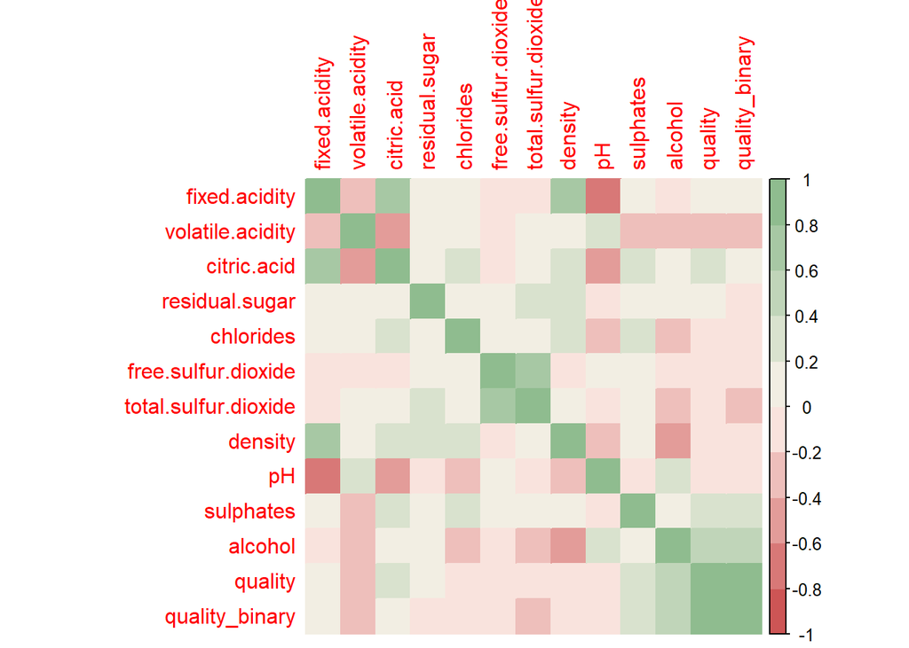

```r
#wine_cor <- round(cor(wine),2)
col <- colorRampPalette(c("indianred3","seashell1","darkseagreen"))(10)
corrplot(cor(wine),method="color",col=col)
```

```r
kable(round(cor(wine),2),caption="Correlation Matrix") %>%
kable_styling(bootstrap_options = c("striped", "hover"))
```

Correlation Matrix

|  | fixed.acidity | volatile.acidity | citric.acid | residual.sugar | chlorides | free.sulfur.dioxide | total.sulfur.dioxide | density | pH | sulphates | alcohol | quality | quality_binary |
| --- | --- | --- | --- | --- | --- | --- | --- | --- | --- | --- | --- | --- | --- |
| fixed.acidity | 1.00 | -0.26 | 0.67 | 0.11 | 0.09 | -0.15 | -0.11 | 0.67 | -0.68 | 0.18 | -0.06 | 0.12 | 0.10 |
| volatile.acidity | -0.26 | 1.00 | -0.55 | 0.00 | 0.06 | -0.01 | 0.08 | 0.02 | 0.23 | -0.26 | -0.20 | -0.39 | -0.32 |
| citric.acid | 0.67 | -0.55 | 1.00 | 0.14 | 0.20 | -0.06 | 0.04 | 0.36 | -0.54 | 0.31 | 0.11 | 0.23 | 0.16 |
| residual.sugar | 0.11 | 0.00 | 0.14 | 1.00 | 0.06 | 0.19 | 0.20 | 0.36 | -0.09 | 0.01 | 0.04 | 0.01 | 0.00 |
| chlorides | 0.09 | 0.06 | 0.20 | 0.06 | 1.00 | 0.01 | 0.05 | 0.20 | -0.27 | 0.37 | -0.22 | -0.13 | -0.11 |
| free.sulfur.dioxide | -0.15 | -0.01 | -0.06 | 0.19 | 0.01 | 1.00 | 0.67 | -0.02 | 0.07 | 0.05 | -0.07 | -0.05 | -0.06 |
| total.sulfur.dioxide | -0.11 | 0.08 | 0.04 | 0.20 | 0.05 | 0.67 | 1.00 | 0.07 | -0.07 | 0.04 | -0.21 | -0.19 | -0.23 |
| density | 0.67 | 0.02 | 0.36 | 0.36 | 0.20 | -0.02 | 0.07 | 1.00 | -0.34 | 0.15 | -0.50 | -0.17 | -0.16 |
| pH | -0.68 | 0.23 | -0.54 | -0.09 | -0.27 | 0.07 | -0.07 | -0.34 | 1.00 | -0.20 | 0.21 | -0.06 | 0.00 |
| sulphates | 0.18 | -0.26 | 0.31 | 0.01 | 0.37 | 0.05 | 0.04 | 0.15 | -0.20 | 1.00 | 0.09 | 0.25 | 0.22 |
| alcohol | -0.06 | -0.20 | 0.11 | 0.04 | -0.22 | -0.07 | -0.21 | -0.50 | 0.21 | 0.09 | 1.00 | 0.48 | 0.43 |
| quality | 0.12 | -0.39 | 0.23 | 0.01 | -0.13 | -0.05 | -0.19 | -0.17 | -0.06 | 0.25 | 0.48 | 1.00 | 0.85 |
| quality_binary | 0.10 | -0.32 | 0.16 | 0.00 | -0.11 | -0.06 | -0.23 | -0.16 | 0.00 | 0.22 | 0.43 | 0.85 | 1.00 |

# Logistic Regression

I created a logistic regression model that would classify wine samples as low and high quality based on all descriptive predictors in the dataset. As expected, **alcohol** and **volatile.acidity** were very significant along with additional variables like **citric.acid**, **chlorides**, **free.sulfur.dioxide**, **total.sulfur,dioxide**, and **sulphates**.

```r
wine.log <- glm(quality_binary~.-quality,data=wine,family=binomial)
summary(wine.log)
```

```
##
## Call:
## glm(formula = quality_binary ~ . - quality, family = binomial,
##     data = wine)
##
## Deviance Residuals:
##     Min       1Q   Median       3Q      Max
## -3.4025  -0.8387   0.3105   0.8300   2.3142
##
## Coefficients:
##                        Estimate Std. Error z value Pr(>|z|)
## (Intercept)           42.949948  79.473979   0.540  0.58890
## fixed.acidity          0.135980   0.098483   1.381  0.16736
## volatile.acidity      -3.281694   0.488214  -6.722 1.79e-11 ***
## citric.acid           -1.274347   0.562730  -2.265  0.02354 *
## residual.sugar         0.055326   0.053770   1.029  0.30351
## chlorides             -3.915713   1.569298  -2.495  0.01259 *
## free.sulfur.dioxide    0.022220   0.008236   2.698  0.00698 **
## total.sulfur.dioxide  -0.016394   0.002882  -5.688 1.29e-08 ***
## density              -50.932385  81.148745  -0.628  0.53024
## pH                    -0.380608   0.720203  -0.528  0.59717
## sulphates              2.795107   0.452184   6.181 6.36e-10 ***
## alcohol                0.866822   0.104190   8.320  < 2e-16 ***
## ---
## Signif. codes:  0 '***' 0.001 '**' 0.01 '*' 0.05 '.' 0.1 ' ' 1
##
## (Dispersion parameter for binomial family taken to be 1)
##
##     Null deviance: 2209.0  on 1598  degrees of freedom
## Residual deviance: 1655.6  on 1587  degrees of freedom
## AIC: 1679.6
##
## Number of Fisher Scoring iterations: 4
```

The **fixed acidity** variable has a high VIF which indicated multicolinearity and must be dropped from further analysis to meet the logistic regression assumptions.

```r
kable(vif(wine.log),caption="VIF") %>%
kable_styling(bootstrap_options = c("striped", "hover"))
```

VIF

|  | x |
| --- | --- |
| fixed.acidity | 7.969336 |
| volatile.acidity | 1.777262 |
| citric.acid | 3.279780 |
| residual.sugar | 1.720504 |
| chlorides | 1.576255 |
| free.sulfur.dioxide | 2.014575 |
| total.sulfur.dioxide | 2.190910 |
| density | 5.768060 |
| pH | 3.439139 |
| sulphates | 1.481575 |
| alcohol | 2.289708 |

```r
wine.log <- glm(quality_binary~.-quality-fixed.acidity-residual.sugar-density-pH-citric.acid,data=wine,family=binomial)
summary(wine.log)
```

```
##
## Call:
## glm(formula = quality_binary ~ . - quality - fixed.acidity -
##     residual.sugar - density - pH - citric.acid, family = binomial,
##     data = wine)
##
## Deviance Residuals:
##     Min       1Q   Median       3Q      Max
## -3.0827  -0.8539   0.3241   0.8369   2.3080
##
## Coefficients:
##                       Estimate Std. Error z value Pr(>|z|)
## (Intercept)          -8.149844   0.809006 -10.074  < 2e-16 ***
## volatile.acidity     -2.895939   0.370675  -7.813 5.60e-15 ***
## chlorides            -4.421027   1.432052  -3.087  0.00202 **
## free.sulfur.dioxide   0.023862   0.007987   2.988  0.00281 **
## total.sulfur.dioxide -0.017505   0.002707  -6.468 9.95e-11 ***
## sulphates             2.705876   0.427543   6.329 2.47e-10 ***
## alcohol               0.859379   0.070725  12.151  < 2e-16 ***
## ---
## Signif. codes:  0 '***' 0.001 '**' 0.01 '*' 0.05 '.' 0.1 ' ' 1
##
## (Dispersion parameter for binomial family taken to be 1)
##
##     Null deviance: 2209.0  on 1598  degrees of freedom
## Residual deviance: 1664.7  on 1592  degrees of freedom
## AIC: 1678.7
##
## Number of Fisher Scoring iterations: 4
```

The final model includes only significant variables and increases classification power. With only significant variables in the first model, **citric.acid** became insignificant and was removed. **alcohol** is the most significant variable and can be interpreted as follows:

- A 1 unit increase in alcohol level in a wine sample results in a 0.87 increase in the log odds of the sample being a high quality wine.

## Predictions

```r
wine.log.probs <- predict(wine.log,type="response")

first10preds <- cbind(wine.log.probs[1:10],wine$quality_binary[1:10])
names(first10preds) <- c("Predicted Pobability","Actual")

kable(first10preds,caption="Probability Predictions and Actuals") %>%
kable_styling(bootstrap_options = c("striped", "hover"))
```

Probability Predictions and Actuals

| 0.2223116 | 0 |
| --- | --- |
| 0.1906291 | 0 |
| 0.2379203 | 0 |
| 0.5135901 | 1 |
| 0.2223116 | 0 |
| 0.2333850 | 0 |
| 0.1758856 | 0 |
| 0.3861074 | 1 |
| 0.3667665 | 1 |
| 0.4741705 | 0 |

```r
#contrasts(quality_binary)  ##quality_binary is already binomial

wine.log.pred <- rep(0,nrow(wine))

#setting class labels
wine.log.pred[wine.log.probs>.5]=1
```

However, on the entire dataset, this model seems to do fairly well at classifying wine quality.

Accuracy = 0.7498437

```r
#Confusion Matrix

kable(table(wine.log.pred,wine$quality_binary),caption="Confusion Matrix")%>%
kable_styling(bootstrap_options = c("striped", "hover"))
```

Confusion Matrix

|  | 0 | 1 |
| --- | --- | --- |
| 0 | 559 | 215 |
| 1 | 185 | 640 |

# Train/Test Split

However, the accuracy is not the most accurate metric for this model. The model is fit on the entire dataset and therefore has not been tested on unseen data. To validate accuracy and prevent overfitting, I split the data into a test and train set. The model will be fit on the train set and the test set will be used to determine accuracy. I used a random sample of 20% of my data to test which resulted in 319 instances.

```r
set.seed(100)
train_ind <- sample(seq_len(nrow(wine)),size=(0.2*nrow(wine)))

test <- wine[train_ind,]
train <- wine[-train_ind,]


kable(head(train),caption="Train Set")%>%
kable_styling(bootstrap_options = c("striped", "hover"))
```

Train Set

| fixed.acidity | volatile.acidity | citric.acid | residual.sugar | chlorides | free.sulfur.dioxide | total.sulfur.dioxide | density | pH | sulphates | alcohol | quality | quality_binary |
| --- | --- | --- | --- | --- | --- | --- | --- | --- | --- | --- | --- | --- |
| 7.4 | 0.70 | 0.00 | 1.9 | 0.076 | 11 | 34 | 0.9978 | 3.51 | 0.56 | 9.4 | 5 | 0 |
| 7.8 | 0.88 | 0.00 | 2.6 | 0.098 | 25 | 67 | 0.9968 | 3.20 | 0.68 | 9.8 | 5 | 0 |
| 7.8 | 0.76 | 0.04 | 2.3 | 0.092 | 15 | 54 | 0.9970 | 3.26 | 0.65 | 9.8 | 5 | 0 |
| 11.2 | 0.28 | 0.56 | 1.9 | 0.075 | 17 | 60 | 0.9980 | 3.16 | 0.58 | 9.8 | 6 | 1 |
| 7.4 | 0.70 | 0.00 | 1.9 | 0.076 | 11 | 34 | 0.9978 | 3.51 | 0.56 | 9.4 | 5 | 0 |
| 7.4 | 0.66 | 0.00 | 1.8 | 0.075 | 13 | 40 | 0.9978 | 3.51 | 0.56 | 9.4 | 5 | 0 |

```r
#nrow(train)

kable(head(test),caption="Test Set")%>%
kable_styling(bootstrap_options = c("striped", "hover"))
```

Test Set

|  | fixed.acidity | volatile.acidity | citric.acid | residual.sugar | chlorides | free.sulfur.dioxide | total.sulfur.dioxide | density | pH | sulphates | alcohol | quality | quality_binary |
| --- | --- | --- | --- | --- | --- | --- | --- | --- | --- | --- | --- | --- | --- |
| 493 | 8.9 | 0.400 | 0.51 | 2.6 | 0.052 | 13 | 27 | 0.99500 | 3.32 | 0.90 | 13.4 | 7 | 1 |
| 412 | 9.1 | 0.450 | 0.35 | 2.4 | 0.080 | 23 | 78 | 0.99870 | 3.38 | 0.62 | 9.5 | 5 | 0 |
| 883 | 8.4 | 0.310 | 0.29 | 3.1 | 0.194 | 14 | 26 | 0.99536 | 3.22 | 0.78 | 12.0 | 6 | 1 |
| 90 | 7.0 | 0.620 | 0.08 | 1.8 | 0.076 | 8 | 24 | 0.99780 | 3.48 | 0.53 | 9.0 | 5 | 0 |
| 748 | 8.6 | 0.330 | 0.40 | 2.6 | 0.083 | 16 | 68 | 0.99782 | 3.30 | 0.48 | 9.4 | 5 | 0 |
| 772 | 9.4 | 0.685 | 0.26 | 2.4 | 0.082 | 23 | 143 | 0.99780 | 3.28 | 0.55 | 9.4 | 5 | 0 |

```r
#nrow(test)
```

# Logistic Regression on Train Set

I created a logistic regression on the train set with all predictor variables and now I have a different set of significant variables.

```r
wine.log2 <- glm(quality_binary~.-quality,data=train,family=binomial)
summary(wine.log2)
```

```
##
## Call:
## glm(formula = quality_binary ~ . - quality, family = binomial,
##     data = train)
##
## Deviance Residuals:
##     Min       1Q   Median       3Q      Max
## -3.3367  -0.8462   0.3208   0.8498   2.3358
##
## Coefficients:
##                       Estimate Std. Error z value Pr(>|z|)
## (Intercept)           0.279192  89.635101   0.003  0.99751
## fixed.acidity         0.092788   0.111050   0.836  0.40341
## volatile.acidity     -3.503173   0.548968  -6.381 1.76e-10 ***
## citric.acid          -1.510899   0.631001  -2.394  0.01665 *
## residual.sugar        0.049831   0.062339   0.799  0.42408
## chlorides            -4.802055   1.846960  -2.600  0.00932 **
## free.sulfur.dioxide   0.020332   0.009182   2.214  0.02680 *
## total.sulfur.dioxide -0.014356   0.003131  -4.585 4.54e-06 ***
## density              -6.782965  91.483042  -0.074  0.94090
## pH                   -0.637383   0.800624  -0.796  0.42597
## sulphates             2.687619   0.508759   5.283 1.27e-07 ***
## alcohol               0.880501   0.117717   7.480 7.44e-14 ***
## ---
## Signif. codes:  0 '***' 0.001 '**' 0.01 '*' 0.05 '.' 0.1 ' ' 1
##
## (Dispersion parameter for binomial family taken to be 1)
##
##     Null deviance: 1769.5  on 1279  degrees of freedom
## Residual deviance: 1341.6  on 1268  degrees of freedom
## AIC: 1365.6
##
## Number of Fisher Scoring iterations: 4
```

I narrowed the model down to include only significant variables. Citric acid became insignificant again and was removed.

```r
wine.log2 <- glm(quality_binary~.-quality-fixed.acidity-residual.sugar-chlorides-density-pH-citric.acid,data=train,family=binomial)
summary(wine.log2)
```

```
##
## Call:
## glm(formula = quality_binary ~ . - quality - fixed.acidity -
##     residual.sugar - chlorides - density - pH - citric.acid,
##     family = binomial, data = train)
##
## Deviance Residuals:
##     Min       1Q   Median       3Q      Max
## -3.1152  -0.8732   0.3137   0.8705   2.3671
##
## Coefficients:
##                       Estimate Std. Error z value Pr(>|z|)
## (Intercept)          -8.322824   0.883460  -9.421  < 2e-16 ***
## volatile.acidity     -3.066701   0.411050  -7.461 8.61e-14 ***
## free.sulfur.dioxide   0.022323   0.008724   2.559   0.0105 *
## total.sulfur.dioxide -0.015277   0.002863  -5.335 9.55e-08 ***
## sulphates             1.894927   0.410970   4.611 4.01e-06 ***
## alcohol               0.890805   0.076830  11.594  < 2e-16 ***
## ---
## Signif. codes:  0 '***' 0.001 '**' 0.01 '*' 0.05 '.' 0.1 ' ' 1
##
## (Dispersion parameter for binomial family taken to be 1)
##
##     Null deviance: 1769.5  on 1279  degrees of freedom
## Residual deviance: 1360.8  on 1274  degrees of freedom
## AIC: 1372.8
##
## Number of Fisher Scoring iterations: 4
```

```r
wine.log2.probs <- predict(wine.log2,test,type="response")


wine.log2.pred <- rep(0,nrow(test))

#setting class labels
wine.log2.pred[wine.log2.probs>.5]=1


#confusion matrix
#accuracy

kable(table(wine.log2.pred,test$quality_binary),caption="Confusion Matrix")%>%
kable_styling(bootstrap_options = c("striped", "hover"))
```

Confusion Matrix

|  | 0 | 1 |
| --- | --- | --- |
| 0 | 110 | 43 |
| 1 | 34 | 132 |

The following plot is the ROC curve for the final logistic regression model.

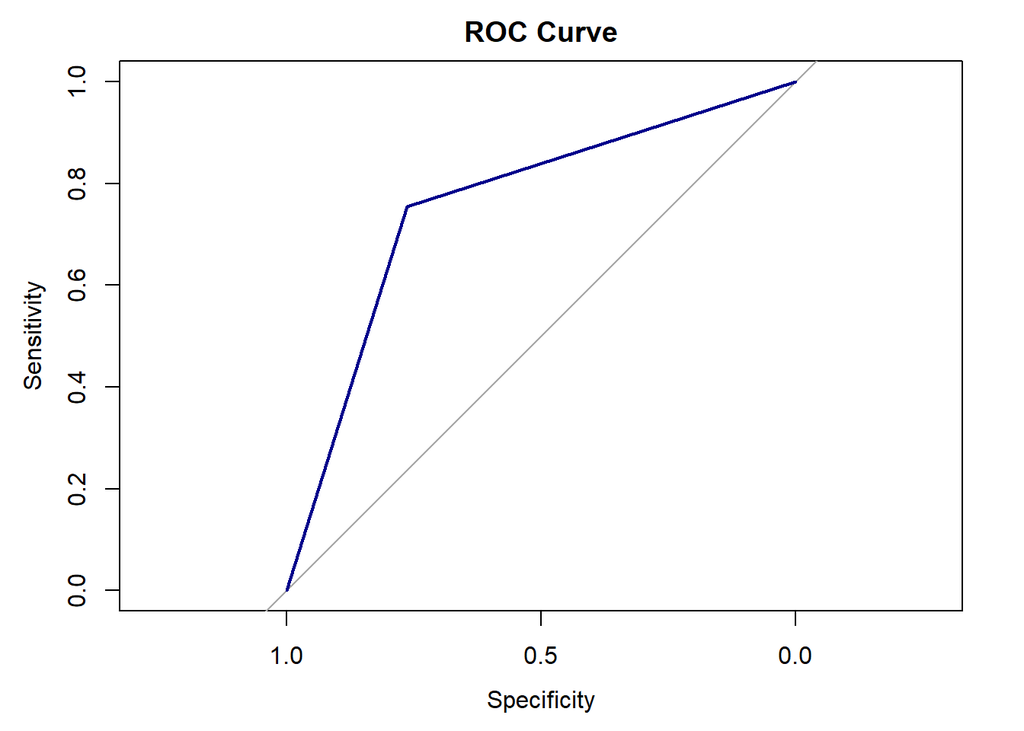

```r
plot(roc(test$quality_binary,wine.log2.pred),main="ROC Curve",col="darkblue")
```

# Linear Discriminat Analysis

Next, I used a Linear Discriminant Analysis (LDA) model to try to classify wine quality. I will continue to use the same variables in the train set while testing on the test set to find the true accuracy of the model.

```r
wine.lda = lda(quality_binary~.-quality-fixed.acidity-residual.sugar-chlorides-density-pH-citric.acid,data=train)
wine.lda
```

```
## Call:
## lda(quality_binary ~ . - quality - fixed.acidity - residual.sugar -
##     chlorides - density - pH - citric.acid, data = train)
##
## Prior probabilities of groups:
##       0       1
## 0.46875 0.53125
##
## Group means:
##   volatile.acidity free.sulfur.dioxide total.sulfur.dioxide sulphates
## 0        0.5910500            16.48500             54.26667 0.6171000
## 1        0.4747647            15.37279             39.98971 0.6893088
##     alcohol
## 0  9.931167
## 1 10.844265
##
## Coefficients of linear discriminants:
##                              LD1
## volatile.acidity     -2.51574039
## free.sulfur.dioxide   0.02053809
## total.sulfur.dioxide -0.01340926
## sulphates             1.70196144
## alcohol               0.71584167
```

-2.5157404$*$**volatile.acidity** $+$ 0.0205381$*$**free.sulfue.dioxide** $+$ -0.0134093$*$**total.sulfur.dioxide** $+$ 1.7019614$*$**sulphates** $+$ 0.7158417$*$**alcohol**

The Plots of linear discriminants display a clear difference between the two wine quality classes. Low quality wines are centered around -1 whereas high quality wines are centered around 1.

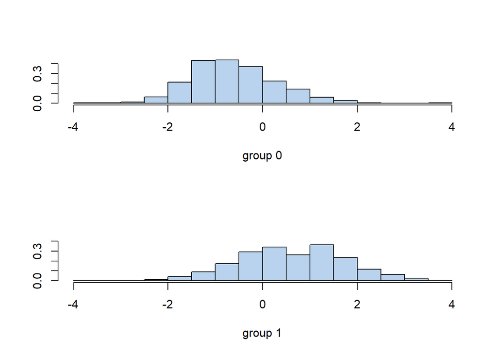

```r
plot(wine.lda,col="slategray2")
```

```r
#LDA Predictions
wine.lda.pred <- predict(wine.lda,test)
```

```r
#confusion matrix
kable(table(wine.lda.pred$class,test$quality_binary),caption="Confusion Matrix")%>%
kable_styling(bootstrap_options = c("striped", "hover"))
```

Confusion Matrix

|  | 0 | 1 |
| --- | --- | --- |
| 0 | 110 | 44 |
| 1 | 34 | 131 |

```r
sum(wine.lda.pred$posterior[,1]>=.5)
```

```
## [1] 154
```

```r
sum(wine.lda.pred$posterior[,1]<.5)
```

```
## [1] 165
```

# Quadratic Discriminant Analysis with all variables

The quadratic discriminant analysis model is similar to the linear discriminant analysis model, except it does not assume that the predictor variables are linearly related to the response variables.

```r
wine.qda <- qda(quality_binary~.-quality,data=train)
wine.qda
```

```
## Call:
## qda(quality_binary ~ . - quality, data = train)
##
## Prior probabilities of groups:
##       0       1
## 0.46875 0.53125
##
## Group means:
##   fixed.acidity volatile.acidity citric.acid residual.sugar  chlorides
## 0      8.154000        0.5910500   0.2382500       2.518083 0.09281833
## 1      8.417059        0.4747647   0.2936471       2.545809 0.08146471
##   free.sulfur.dioxide total.sulfur.dioxide   density       pH sulphates
## 0            16.48500             54.26667 0.9970503 3.308050 0.6171000
## 1            15.37279             39.98971 0.9964686 3.314971 0.6893088
##     alcohol
## 0  9.931167
## 1 10.844265
```

The following confusion matrix displays the predictions of the QDA model vs. the actual values in the test set.

```r
wine.qda.class <- predict(wine.qda,test)$class
kable(table(wine.qda.class,test$quality_binary),caption="Confusion Matrix")%>%
kable_styling(bootstrap_options = c("striped", "hover"))
```

Confusion Matrix

|  | 0 | 1 |
| --- | --- | --- |
| 0 | 90 | 36 |
| 1 | 54 | 139 |

The accuracy of the QDA model turns out to be 0.7178683 which is similar to the LDA model but does not perform as well.

# K-Nearest Neighbors

The K Nearest Neighbors model classifies instances based on a majority vote of instances that are similar. For the kNN model, I will continue to use the train and test set as well as the final set of predictor variables derived from the logistic regression model.

The following kNN model takes in only the predictor variables in the train set and test set separately.

```r
x_vars_train <- train[,c("alcohol","free.sulfur.dioxide","sulphates","total.sulfur.dioxide","volatile.acidity")]
kable(head(x_vars_train),caption="Predictor Variables in Train Set")%>%
kable_styling(bootstrap_options = c("striped", "hover"))
```

Predictor Variables in Train Set

| alcohol | free.sulfur.dioxide | sulphates | total.sulfur.dioxide | volatile.acidity |
| --- | --- | --- | --- | --- |
| 9.4 | 11 | 0.56 | 34 | 0.70 |
| 9.8 | 25 | 0.68 | 67 | 0.88 |
| 9.8 | 15 | 0.65 | 54 | 0.76 |
| 9.8 | 17 | 0.58 | 60 | 0.28 |
| 9.4 | 11 | 0.56 | 34 | 0.70 |
| 9.4 | 13 | 0.56 | 40 | 0.66 |

```r
x_vars_test <- test[,c("alcohol","free.sulfur.dioxide","sulphates","total.sulfur.dioxide","volatile.acidity")]
kable(head(x_vars_test),caption="Predictor Variables in Test Set")%>%
kable_styling(bootstrap_options = c("striped", "hover"))
```

Predictor Variables in Test Set

|  | alcohol | free.sulfur.dioxide | sulphates | total.sulfur.dioxide | volatile.acidity |
| --- | --- | --- | --- | --- | --- |
| 493 | 13.4 | 13 | 0.90 | 27 | 0.400 |
| 412 | 9.5 | 23 | 0.62 | 78 | 0.450 |
| 883 | 12.0 | 14 | 0.78 | 26 | 0.310 |
| 90 | 9.0 | 8 | 0.53 | 24 | 0.620 |
| 748 | 9.4 | 16 | 0.48 | 68 | 0.330 |
| 772 | 9.4 | 23 | 0.55 | 143 | 0.685 |

```r
set.seed(1)
wine.knn.pred <- knn(x_vars_train,x_vars_test,train$quality_binary,k=1)
```

The following confusion matrix displays displays the predictions of the kNN model when k=1 vs. the actual values in the test set. The model results in an accuracy of 0.69279.

```r
#Confusion Matrix
kable(table(wine.knn.pred,test$quality_binary))%>%
kable_styling(bootstrap_options = c("striped", "hover"))
```

|  | 0 | 1 |
| --- | --- | --- |
| 0 | 98 | 52 |
| 1 | 46 | 123 |

To test for the best value of k, I plotted k against accuracy for k=1:100. k=1 results in the best accuracy.

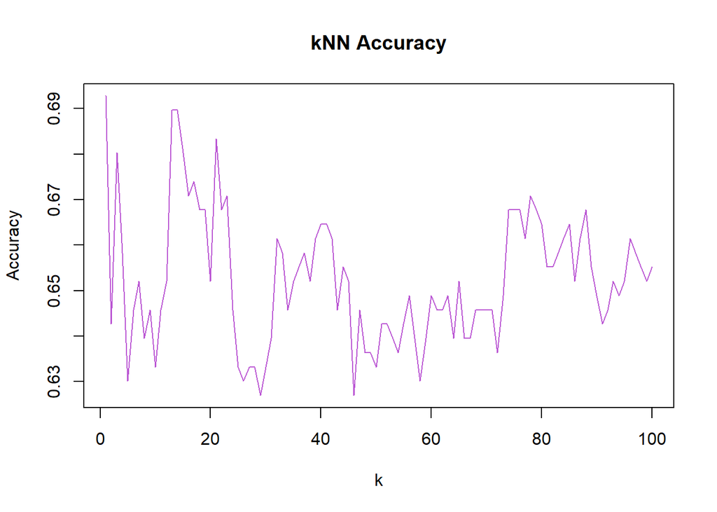

```r
knn_x <- vector()
knn_y <- vector()

for(i in 1:100){
  wine.knn.pred <- knn(x_vars_train,x_vars_test,train$quality_binary,k=i)
  mean(wine.knn.pred==test$quality_binary)
  knn_x[i] <- i
  knn_y[i] <- mean(wine.knn.pred==test$quality_binary)
}

plot(knn_x,knn_y,main="kNN Accuracy",ylab="Accuracy",xlab="k",col="mediumorchid",type="l")
```